# Acheta Desiccation

- Show All Code
- Hide All Code
- View Source

Potassium and Sodium

Author

Affiliation

Jacinta Kong

Department of Biology, Carleton Univeristy, Canada

Published

October 14, 2026

# 1 Introduction

Aim: To determine how crickets ionoregulate during desiccation.

Crickets were placed in incubator in glass fly vials filled with ~1 inch of Drierite separated from the cricket by a cotton ball, stoppered with a sponge bung.

## 1.1 Hypothesis

H0: Homoeostasis hypothesis: Ion concentration is regulated under desiccating conditions. Potential mechanisms include supplementation of water to maintain haemolymph volume or sequestration of ion to maintain concentration.

H1: No homeostasis hypothesis: Ion concentration increases proportionally with water loss because haemolymph volume decreases.

## 1.2 Design

```r
righty <- read_csv("data/Desiccation 2025/Ions/Potassium/righty_log_from_20251015_to_20251023_.csv")
names(righty) <- c("Time", "Temp", "RH", "MAC")
# Temperature
summary(righty$Temp)
```

```
   Min. 1st Qu.  Median    Mean 3rd Qu.    Max.
  29.14   29.78   30.21   30.26   30.55   32.52
```

Species: *Acheta domesticus*  
Time: 0, 3, 6, 18 or 24 (rehydrated) hours. Rehydrated crickets were dried for 18 hours then provided water for 6 hours.  
Temperature: 30.3°C  
Sex: Male (blue) or Female (orange)

## 1.3 Variables

Calculate mass in mg from grams:

- Start mass: Mass at the start of the experiment
- End mass: Mass after desiccation
- Rehydrated mass: Mass after rehydration
- Dry mass: Mass after drying in a oven at 60 °C for at least 48 hours

Calculate change in mass between time points:

- Percentage change in wet mass during desiccation
- Percentage change in wet mass from start to end of rehydration

Calculate body water content from dry mass:

- Total water content (%): All fluid in body relative to starting mass
- Relative water loss (%): Body fluid lost during desiccation. Relative to total water content

Calculate water loss rates:

- Mass change rate (%/h): Percentage rate change during desiccation based on wet mass
- Water loss rate; WLR (%/h): Rate of relative water loss during desiccation

```r
# LOAD AND PREPARE
drying_data_all <- read_excel("data/Desiccation 2025/Ions/IonsData.xlsx")[1:15]
names(drying_data_all)[11] <- "Ion_conc"
drying_data_all$Ion <- ifelse(drying_data_all$Ion == "Na+", "Na+", "K+") # Relabel all potassium for consistency

# QUALITY CONTROL
# Remove poor readings and melanised samples
drying_data_all <- drying_data_all %>%
  filter(`Read quality` != "Poor",
         (!`Comment(s)` %in% c("Black","blackened", "Dead before")) %>% replace_na(TRUE))

# Calculate average conc across multiple readings for each ID
drying_data <- drying_data_all %>%
  group_by(Ion, Cricket_ID, Sex, Time) %>%
  summarise(Ion_conc = mean(Ion_conc)) %>%
  ungroup()

# Load mass data
mass_data <- read_excel("data/Desiccation 2025/Ions/IonsData.xlsx", sheet = "mass") %>%
  mutate(Desiccation_time = ifelse(Time == 24, 18, Time))
# Starting mass
mass_data$Start_mass <- (mass_data$Start.Cricket - mass_data$Start.Container) * 1000
# Mass after dehydration
mass_data$End_mass <- (mass_data$End.Cricket - mass_data$End.Container) * 1000
# Mass after rehydration
mass_data$Rehydrated_mass <- (mass_data$Rehydrated.Cricket - mass_data$Rehydrated.Container) * 1000

# Remove outlier sodium females (reasons discussed below)
mass_data <- filter(mass_data, !Cricket_ID  %in% c(334, 399, 441))

# Calculate wet mass metrics (mg)
# Relative change in dehydrated mass to starting mass
mass_data$Percent_change <- ifelse(mass_data$Time == 0, NA, 100 - (mass_data$End_mass / mass_data$Start_mass) * 100)
# Relative change in rehydrated mass to starting mass
mass_data$Percent_change_recovery <- ifelse(mass_data$Time == 24, (mass_data$Rehydrated_mass / mass_data$Start_mass) * 100, NA)

# Calculate dry mass metrics
# Total body water (mg)
mass_data$Body_water <- mass_data$Start_mass - mass_data$Dry_mass_mg
mass_data$Lost_water <- mass_data$Start_mass - mass_data$End_mass
# Total body water (%)
mass_data$Total_water_content <- ((mass_data$Start_mass - mass_data$Dry_mass_mg) / mass_data$Start_mass) * 100
# Water lost during desiccation (%)
mass_data$Relative_water_loss <- (mass_data$Percent_change /  mass_data$Total_water_content) * 100

# Merge and transform data
drying_data <- left_join(mass_data[,-c(4:9)], drying_data, by = c("Cricket_ID", "Sex", "Time"))

# Extract dead crickets
# dead_crickets <- filter(drying_data, is.na(Ion_conc))

drying_data <- drying_data %>%
  drop_na(Ion_conc) %>%
  # Exclude individuals that did not have ion concentration measured
  mutate(Time_fct = factor(Time, levels = c("0", "3", "6", "18", "24")),
         log_ion = log10(Ion_conc),
         log_PC = log10(Percent_change))
```

### 1.3.1 Cleaning data

Causes of exclusion:

- Death at any time; the time of death is unknown and mass could be overestimated.
- Dying - tended to have insufficient haemolymph. Alive and responsive but lethargic and with splayed legs indicating muscle issues (hyperkalemia?).
- Insufficient haemolymph; alive and responsive and not lethargic but haemocoel was empty.
- Poor quality readings; drifting electrode with no stable reading for 10 seconds
- Sample heavily melanised. Sodium is sensitive to melanisation (increases). Potassium concentration is stable over time.

K+:

- One male was excluded with >100 mM K<sup>+</sup>, this is a valid datapoint and measured multiple times.
- Cricket 434 died at the start of the experiment, haemolymph was sampled and frozen and had ions measured but theses are excluded from analysis. [K<sup>+</sup>] was higher than other crickets >100 mM K<sup>+</sup>
- 201 crickets measured

Na+:

- Cricket 350 was measured with a good read on a dodgy electrode but has abnormally low sodium. Was removed.
- Cricket 441 was measured with a good read but has abnormally low sodium. Was removed.
- Cricket 334 was injured in the vial. Leg fell off. Had abnormally high water loss and high sodium. Removed from analysis.
- Cricket 399 had abnormally high water loss and high sodium. Removed from analysis.
- 193 crickets measured

Checking distributions:

- K<sup>+</sup> concentration is right skewed, still right skewed after Log 10 transformation but transformed.
- Na<sup>+</sup> concentration is not skewed, Log 10 transformed anyway.
- Mass percent change is right skewed. Normally distributed after Log 10 transformation.
- Water loss rate is right skewed. More normally distributed after Log 10 transformation.

# 2 Ion concentration

- Overall crickets are good regulators; magnitude of concentration changes are small
- Sex differences; females have higher concentrations of potassium and similar concentrations of sodium to males
- Variation around the mean is smaller in sodium. Variation in potassium is high in females.
- Potassium does not change with longer desiccation or rehydration
- Sodium increases in females then returns to baseline levels after rehydration
- Sodium in males increases then returns to baseline levels after rehydration

## 2.1 Calculate mean and standard error

```r
mean_ion_conc <- drying_data %>%
  group_by(Ion, Sex, Time) %>%
  summarise(mean_conc = mean(Ion_conc),
            se_conc = sd(Ion_conc) / sqrt(n()),
            range = max(Ion_conc) - min(Ion_conc),
            n = n())
```

```r
knitr::kable(mean_ion_conc, digits = 3)
```

| Ion | Sex | Time | mean_conc | se_conc | range | n |
| --- | --- | --- | --- | --- | --- | --- |
| K+ | Female | 0 | 10.220 | 1.548 | 23.513 | 20 |
| K+ | Female | 3 | 10.825 | 1.900 | 32.014 | 20 |
| K+ | Female | 6 | 10.495 | 2.310 | 37.199 | 21 |
| K+ | Female | 18 | 8.703 | 0.960 | 17.580 | 20 |
| K+ | Female | 24 | 8.720 | 0.971 | 13.598 | 18 |
| K+ | Male | 0 | 6.461 | 0.231 | 5.883 | 28 |
| K+ | Male | 3 | 6.719 | 0.223 | 3.425 | 17 |
| K+ | Male | 6 | 7.095 | 0.568 | 10.938 | 19 |
| K+ | Male | 18 | 7.783 | 0.317 | 4.859 | 19 |
| K+ | Male | 24 | 6.588 | 0.259 | 4.372 | 19 |
| Na+ | Female | 0 | 155.939 | 2.976 | 44.425 | 20 |
| Na+ | Female | 3 | 166.773 | 2.155 | 35.916 | 19 |
| Na+ | Female | 6 | 167.537 | 2.666 | 38.102 | 19 |
| Na+ | Female | 18 | 177.990 | 2.259 | 34.421 | 19 |
| Na+ | Female | 24 | 162.412 | 2.701 | 36.939 | 18 |
| Na+ | Male | 0 | 163.666 | 2.396 | 31.767 | 19 |
| Na+ | Male | 3 | 180.242 | 3.048 | 48.458 | 20 |
| Na+ | Male | 6 | 163.057 | 3.051 | 52.750 | 20 |
| Na+ | Male | 18 | 175.164 | 2.564 | 40.091 | 20 |
| Na+ | Male | 24 | 167.159 | 3.355 | 44.686 | 19 |

## 2.2 Does ion concentration change over time?

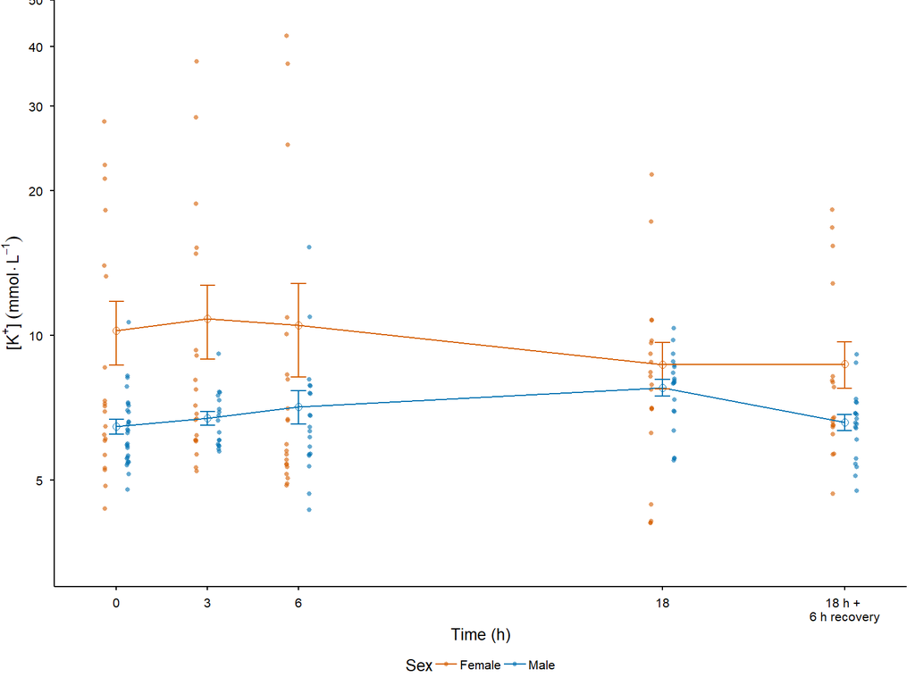

Potassium concentration (mM) for males (blue) and females (orange) does not increase with longer desiccation. Females have higher potassium concentration than males. Error bars are standard error around the mean.

```r
p_potassium <- ggplot() +
  geom_point(data = filter(drying_data, Ion == "K+"), aes(Time, Ion_conc, colour = Sex), alpha = 0.6, stroke = NA,
             position = position_jitterdodge(jitter.height = 0, jitter.width = 0.1, dodge = 1.5)) +
  geom_point(data = filter(mean_ion_conc, Ion == "K+"), aes(Time, mean_conc, group = Sex, colour = Sex),
             size = 2, shape = 1, show.legend = FALSE,
             position = position_dodge(0)) +
  geom_line(data = filter(mean_ion_conc, Ion == "K+"), aes(Time, mean_conc, group = Sex, colour = Sex),
                position = position_dodge(0), linewidth = 0.5) +
  geom_errorbar(data = filter(mean_ion_conc, Ion == "K+"), aes(Time, group = Sex, colour = Sex,
                                      ymin = mean_conc - se_conc,
                                      ymax = mean_conc + se_conc),
                width = 1, linewidth = 0.5,
                position = position_dodge(0)) +
  labs(y = expression("[K"^"+"*"]" ~ ("mmol"%.%"L"^-1))) +
  scale_shape_manual(values = sex_point) +
  scale_colour_manual(values = sex_pal) +
  scale_y_log10(limits = c(3, 50), breaks = c(5, seq(10, 50, 10)), expand = expansion(mult = c(0, 0))) +
  scale_x_continuous(name = "Time (h)", breaks = c(0, 3, 6, 18, 24), labels = c("0", "3", "6", "18", "18 h + \n6 h recovery"))

p_potassium
```

```r
test <- data.frame(Time = rep(c(0, 3, 6, 18, 24), 2), conc = 215, Sex = c(rep("Male", 5), rep("Female", 5)), pair = c("a", "b", "a", "b", "a", "a", "b", "b", "c", "a"))
```

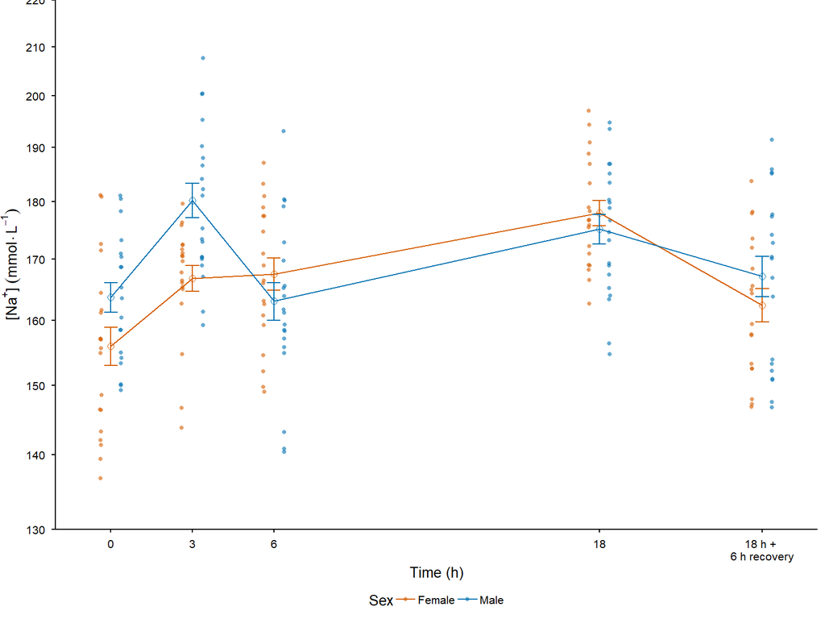

Sodium concentration (mM) increases over time for males (blue) and females (orange). Concentration returns to baseline levels after rehydration. Error bars are standard error around the mean.

```r
p_sodium <- ggplot() +
  geom_point(data = filter(drying_data, Ion == "Na+"), aes(Time, Ion_conc, colour = Sex), alpha = 0.6, stroke = NA,
             position = position_jitterdodge(jitter.height = 0, jitter.width = 0.1, dodge = 1.5)) +
  geom_point(data = filter(mean_ion_conc, Ion == "Na+"), aes(Time, mean_conc, group = Sex, colour = Sex),
             size = 2, shape = 1, show.legend = FALSE,
             position = position_dodge(0)) +
  geom_line(data = filter(mean_ion_conc, Ion == "Na+"), aes(Time, mean_conc, group = Sex, colour = Sex),
                position = position_dodge(0), linewidth = 0.5) +
  geom_errorbar(data = filter(mean_ion_conc, Ion == "Na+"), aes(Time, group = Sex, colour = Sex,
                                      ymin = mean_conc - se_conc,
                                      ymax = mean_conc + se_conc),
                width = 1, linewidth = 0.5,
                position = position_dodge(0)) +
  labs(y = expression("[Na"^"+"*"]" ~ ("mmol"%.%"L"^-1))) +
  scale_colour_manual(values = sex_pal) +
  scale_y_log10(limits = c(130, 220), breaks = seq(100, 300, 10), expand = expansion(mult = c(0, 0))) +
  scale_x_continuous(name ="Time (h)", breaks = c(0, 3, 6, 18, 24), labels = c("0", "3", "6", "18", "18 h + \n6 h recovery"))
# +  geom_text(data = test, aes(Time, conc, label = pair, colour = Sex), position = position_dodge(width = 1), show.legend = FALSE)

p_sodium
```

### 2.2.1 Stats

Count time as a continuous variable. Use categorical for HSD.

Potassium:

No interaction.

```r
# Potassium
drying_data %>%
  filter(Ion == "K+") %>%
  lm(log_ion ~ Time + Sex, .) %>%
  anova() %>%
  knitr::kable(digits = 3)
```

|  | Df | Sum Sq | Mean Sq | F value | Pr(>F) |
| --- | --- | --- | --- | --- | --- |
| Time | 1 | 0.000 | 0.000 | 0.000 | 0.997 |
| Sex | 1 | 0.402 | 0.402 | 13.366 | 0.000 |
| Residuals | 198 | 5.949 | 0.030 | NA | NA |

```r
drying_data %>%
  filter(Ion == "K+") %>%
  lm(log_ion ~ Time_fct + Sex, .) %>%
  anova()
```

```
Analysis of Variance Table

Response: log_ion
           Df Sum Sq Mean Sq F value    Pr(>F)
Time_fct    4 0.0484 0.01211  0.3991 0.8091157
Sex         1 0.3866 0.38656 12.7417 0.0004502 ***
Residuals 195 5.9160 0.03034
---
Signif. codes:  0 '***' 0.001 '**' 0.01 '*' 0.05 '.' 0.1 ' ' 1
```

```r
pairs(emmeans(lm(log_ion ~ Time_fct * Sex, filter(drying_data, Ion == "K+")), ~ Time_fct * Sex), simple = "Time_fct", adjust = "Tukey")
```

```
Sex = Female:
 contrast                estimate     SE  df t.ratio p.value
 Time_fct0 - Time_fct3   -0.01766 0.0552 191  -0.320  0.9977
 Time_fct0 - Time_fct6    0.03185 0.0546 191   0.584  0.9773
 Time_fct0 - Time_fct18   0.03657 0.0552 191   0.662  0.9641
 Time_fct0 - Time_fct24   0.03037 0.0567 191   0.535  0.9836
 Time_fct3 - Time_fct6    0.04951 0.0546 191   0.908  0.8937
 Time_fct3 - Time_fct18   0.05423 0.0552 191   0.982  0.8631
 Time_fct3 - Time_fct24   0.04803 0.0567 191   0.847  0.9156
 Time_fct6 - Time_fct18   0.00472 0.0546 191   0.087  1.0000
 Time_fct6 - Time_fct24  -0.00148 0.0561 191  -0.026  1.0000
 Time_fct18 - Time_fct24 -0.00620 0.0567 191  -0.109  1.0000

Sex = Male:
 contrast                estimate     SE  df t.ratio p.value
 Time_fct0 - Time_fct3   -0.02007 0.0537 191  -0.374  0.9958
 Time_fct0 - Time_fct6   -0.02793 0.0519 191  -0.538  0.9832
 Time_fct0 - Time_fct18  -0.08059 0.0519 191  -1.553  0.5295
 Time_fct0 - Time_fct24  -0.00914 0.0519 191  -0.176  0.9998
 Time_fct3 - Time_fct6   -0.00786 0.0583 191  -0.135  0.9999
 Time_fct3 - Time_fct18  -0.06052 0.0583 191  -1.038  0.8373
 Time_fct3 - Time_fct24   0.01093 0.0583 191   0.187  0.9997
 Time_fct6 - Time_fct18  -0.05266 0.0566 191  -0.930  0.8851
 Time_fct6 - Time_fct24   0.01879 0.0566 191   0.332  0.9974
 Time_fct18 - Time_fct24  0.07145 0.0566 191   1.261  0.7152

P value adjustment: tukey method for comparing a family of 5 estimates
```

Sodium:

Interaction present.

```r
# Sodium
drying_data %>%
  filter(Ion == "Na+") %>%
  lm(log_ion ~ Time + Sex, .) %>%
  anova() %>%
  knitr::kable(digits = 3)
```

|  | Df | Sum Sq | Mean Sq | F value | Pr(>F) |
| --- | --- | --- | --- | --- | --- |
| Time | 1 | 0.004 | 0.004 | 3.397 | 0.067 |
| Sex | 1 | 0.005 | 0.005 | 3.657 | 0.057 |
| Residuals | 190 | 0.240 | 0.001 | NA | NA |

```r
drying_data %>%
  filter(Ion == "Na+") %>%
  lm(log_ion ~ Time_fct * Sex, .) %>%
  anova()
```

```
Analysis of Variance Table

Response: log_ion
              Df   Sum Sq   Mean Sq F value         Pr(>F)
Time_fct       4 0.050544 0.0126361 12.8460 0.000000003085 ***
Sex            1 0.004311 0.0043114  4.3830       0.037676 *
Time_fct:Sex   4 0.014307 0.0035767  3.6362       0.007071 **
Residuals    183 0.180009 0.0009837
---
Signif. codes:  0 '***' 0.001 '**' 0.01 '*' 0.05 '.' 0.1 ' ' 1
```

```r
pairs(emmeans(lm(log_ion ~ Time_fct * Sex, filter(drying_data, Ion == "Na+")), ~ Time_fct * Sex), simple = "Time_fct", adjust = "Tukey")
```

```
Sex = Female:
 contrast                estimate      SE  df t.ratio p.value
 Time_fct0 - Time_fct3   -0.02996 0.01000 183  -2.982  0.0266
 Time_fct0 - Time_fct6   -0.03163 0.01000 183  -3.149  0.0162
 Time_fct0 - Time_fct18  -0.05830 0.01000 183  -5.802 <0.0001
 Time_fct0 - Time_fct24  -0.01813 0.01020 183  -1.779  0.3891
 Time_fct3 - Time_fct6   -0.00167 0.01020 183  -0.164  0.9998
 Time_fct3 - Time_fct18  -0.02833 0.01020 183  -2.785  0.0462
 Time_fct3 - Time_fct24   0.01184 0.01030 183   1.147  0.7810
 Time_fct6 - Time_fct18  -0.02666 0.01020 183  -2.620  0.0709
 Time_fct6 - Time_fct24   0.01351 0.01030 183   1.310  0.6857
 Time_fct18 - Time_fct24  0.04017 0.01030 183   3.894  0.0013

Sex = Male:
 contrast                estimate      SE  df t.ratio p.value
 Time_fct0 - Time_fct3   -0.04157 0.01000 183  -4.137  0.0005
 Time_fct0 - Time_fct6    0.00223 0.01000 183   0.221  0.9995
 Time_fct0 - Time_fct18  -0.02943 0.01000 183  -2.929  0.0310
 Time_fct0 - Time_fct24  -0.00842 0.01020 183  -0.828  0.9217
 Time_fct3 - Time_fct6    0.04379 0.00992 183   4.415  0.0002
 Time_fct3 - Time_fct18   0.01214 0.00992 183   1.224  0.7376
 Time_fct3 - Time_fct24   0.03314 0.01000 183   3.298  0.0102
 Time_fct6 - Time_fct18  -0.03166 0.00992 183  -3.192  0.0142
 Time_fct6 - Time_fct24  -0.01065 0.01000 183  -1.060  0.8267
 Time_fct18 - Time_fct24  0.02101 0.01000 183   2.091  0.2286

P value adjustment: tukey method for comparing a family of 5 estimates
```

## 2.3 Does ion concentration change proportionally with mass lost?

H0: If crickets are not maintaining homeostasis, then ion concentration should increase proportionally with water lost during desiccation. Indicating that haemolymph is concentrating in the haemocoel. Slopes should be the same as 1 and different to 0.

H1: If crickets are maintaining homeostasis, then ion concentration should not have a relationship with water lost. Slopes should be similar to 0 or different to 1.

**Conclusion:**  
Haemolymph potassium is being regulated. Slopes are not different to 0 and different to 1. Crickets are not regulating sodium. Slope is different to 0 and different to 1. Thus, sodium concentration is not proportional to amount of water lost during desiccation.

### 2.3.1 Potassium:

```r
# Potassium equation
# Interaction term non-significant, dropped from model.
Kmass_data <- drying_data %>%
  filter(Ion == "K+",
         !Time %in% c("0", "24")) %>%
  mutate(ln_waterloss = log(Relative_water_loss),
         ln_ion = log(Ion_conc))

Kmass_mod <- lm(ln_ion ~ ln_waterloss, Kmass_data)
summary(Kmass_mod)
```

```
Call:
lm(formula = ln_ion ~ ln_waterloss, data = Kmass_data)

Residuals:
     Min       1Q   Median       3Q      Max
-0.62230 -0.27087 -0.08431  0.10962  1.69299

Coefficients:
             Estimate Std. Error t value            Pr(>|t|)
(Intercept)   2.06835    0.11360  18.208 <0.0000000000000002 ***
ln_waterloss -0.01606    0.05222  -0.308               0.759
---
Signif. codes:  0 '***' 0.001 '**' 0.01 '*' 0.05 '.' 0.1 ' ' 1

Residual standard error: 0.4376 on 114 degrees of freedom
Multiple R-squared:  0.0008291, Adjusted R-squared:  -0.007936
F-statistic: 0.09459 on 1 and 114 DF,  p-value: 0.759
```

```r
summary(lm((ln_ion-ln_waterloss) ~ ln_waterloss, Kmass_data)) # Slope is non-significant
```

```
Call:
lm(formula = (ln_ion - ln_waterloss) ~ ln_waterloss, data = Kmass_data)

Residuals:
     Min       1Q   Median       3Q      Max
-0.62230 -0.27087 -0.08431  0.10962  1.69299

Coefficients:
             Estimate Std. Error t value            Pr(>|t|)
(Intercept)   2.06835    0.11360   18.21 <0.0000000000000002 ***
ln_waterloss -1.01606    0.05222  -19.46 <0.0000000000000002 ***
---
Signif. codes:  0 '***' 0.001 '**' 0.01 '*' 0.05 '.' 0.1 ' ' 1

Residual standard error: 0.4376 on 114 degrees of freedom
Multiple R-squared:  0.7686,    Adjusted R-squared:  0.7665
F-statistic: 378.6 on 1 and 114 DF,  p-value: < 0.00000000000000022
```

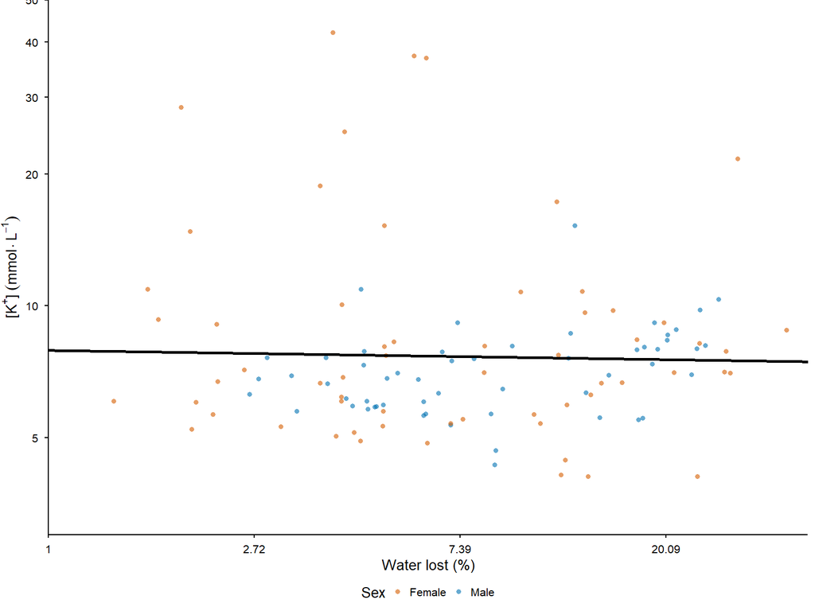

Potassium concentration (mM) against relative water loss (%). Females are orange. Males are blue. Potassium concentration is independent of mass lost for both sexes.

```r
p_KWL <- ggplot() +
  geom_point(data = drying_data[!drying_data$Time %in% c("0", "24") & drying_data$Ion == "K+",], aes(Relative_water_loss, Ion_conc, colour = Sex), alpha = 0.6) +
  geom_abline(colour = "black", linewidth = 1, slope = coef(Kmass_mod)[2], intercept = coef(Kmass_mod)[1]) +
  labs(y = expression("[K"^"+"*"]" ~ ("mmol"%.%"L"^-1)),
       x = "Water lost (%)") +
  scale_y_continuous(trans = "log", limits = c(3, 50), breaks = c(5, seq(0, 150, 10)), expand = expansion(mult = c(0, 0))) +
  scale_x_continuous(trans = "log", limits = c(1, 40), expand = expansion(mult = c(0.0, 0)), labels = function(x) round(x, 2)) +
  scale_colour_manual(values = sex_pal)

p_KWL
```

### 2.3.2 Sodium:

Slope is not equal to 1 but different to 0.

```r
Namass_data <- drying_data %>%
  filter(Ion == "Na+",
         !Time %in% c("0", "24")) %>%
  mutate(ln_waterloss = log(Relative_water_loss),
         ln_ion = log(Ion_conc))

Namass_mod <- lm(ln_ion ~ ln_waterloss, Namass_data)
summary(Namass_mod)
```

```
Call:
lm(formula = ln_ion ~ ln_waterloss, data = Namass_data)

Residuals:
      Min        1Q    Median        3Q       Max
-0.204139 -0.047528  0.008022  0.043873  0.192160

Coefficients:
             Estimate Std. Error t value            Pr(>|t|)
(Intercept)   5.09150    0.02471 206.092 <0.0000000000000002 ***
ln_waterloss  0.02285    0.01041   2.196              0.0301 *
---
Signif. codes:  0 '***' 0.001 '**' 0.01 '*' 0.05 '.' 0.1 ' ' 1

Residual standard error: 0.07572 on 115 degrees of freedom
Multiple R-squared:  0.04024,   Adjusted R-squared:  0.0319
F-statistic: 4.822 on 1 and 115 DF,  p-value: 0.0301
```

```r
summary(lm((ln_ion-ln_waterloss) ~ ln_waterloss, Namass_data)) # Slope is non-significant
```

```
Call:
lm(formula = (ln_ion - ln_waterloss) ~ ln_waterloss, data = Namass_data)

Residuals:
      Min        1Q    Median        3Q       Max
-0.204139 -0.047528  0.008022  0.043873  0.192160

Coefficients:
             Estimate Std. Error t value            Pr(>|t|)
(Intercept)   5.09150    0.02471   206.1 <0.0000000000000002 ***
ln_waterloss -0.97715    0.01041   -93.9 <0.0000000000000002 ***
---
Signif. codes:  0 '***' 0.001 '**' 0.01 '*' 0.05 '.' 0.1 ' ' 1

Residual standard error: 0.07572 on 115 degrees of freedom
Multiple R-squared:  0.9871,    Adjusted R-squared:  0.987
F-statistic:  8818 on 1 and 115 DF,  p-value: < 0.00000000000000022
```

```r
emtrends(Namass_mod, ~1, var = "ln_waterloss") %>%
  test(., null = 1)
```

```
 1       ln_waterloss.trend     SE  df null t.ratio p.value
 overall             0.0229 0.0104 115    1 -93.903 <0.0001
```

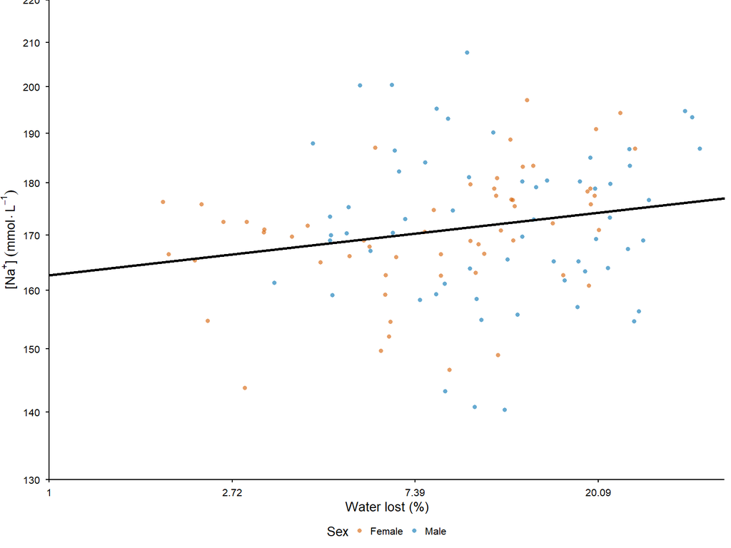

Sodium concentration (mM) against relative water loss (%). Females are orange. Males are blue. Both sexes increase sodium concentration with increasing water loss.

```r
p_NaWL <- ggplot() +
  geom_point(data = drying_data[!drying_data$Time %in% c("0", "24") & drying_data$Ion == "Na+",], aes(Relative_water_loss, Ion_conc, colour = Sex), alpha = 0.6) +
  geom_abline(colour = "black", linewidth = 1, slope = coef(Namass_mod)[2], intercept = coef(Namass_mod)[1]) +
  labs(y = expression("[Na"^"+"*"]" ~ ("mmol"%.%"L"^-1)),
       x = "Water lost (%)") +
  scale_x_continuous(trans = "log", limits = c(1, 40), expand = expansion(mult = c(0.0, 0)), labels = function(x) round(x, 2)) +
  scale_y_continuous(trans = "log", limits = c(130, 220), breaks = seq(100, 300, 10), expand = expansion(mult = c(0, 0))) +
  scale_colour_manual(values = sex_pal)
p_NaWL
```

# 3 Relative change during desiccation

Mass lost is not expected to be linear because osmotic pressure will cause water to be increasingly harder to lose. Therefore, data was analysed assuming a power function and time and mass lost are log transformed.

```r
# Percentage change (wet mass)
mean_pc_loss <- drying_data %>%
  filter(!Time %in% c("0")) %>%
  group_by(Sex, Desiccation_time) %>%
  distinct(Cricket_ID, Percent_change, Sex, Desiccation_time) %>%
  summarise(mean_pc = mean(Percent_change),
            se_pc = sd(Percent_change) / sqrt(n()),
            range = max(Percent_change) - min(Percent_change),
            n = n())

knitr::kable(mean_pc_loss, digits = 3)
```

| Sex | Desiccation_time | mean_pc | se_pc | range | n |
| --- | --- | --- | --- | --- | --- |
| Female | 3 | 2.525 | 0.236 | 6.658 | 39 |
| Female | 6 | 6.166 | 0.524 | 14.429 | 40 |
| Female | 18 | 10.638 | 0.624 | 21.800 | 57 |
| Male | 3 | 4.072 | 0.249 | 6.547 | 37 |
| Male | 6 | 7.427 | 0.487 | 11.462 | 39 |
| Male | 18 | 17.297 | 0.610 | 21.083 | 58 |

There was no interaction between sex and time so the interaction term was dropped from the model.

```r
PC_mod <- drying_data %>%
  filter(!Time %in% c("0")) %>%
  distinct(Cricket_ID, Percent_change, Sex, Desiccation_time) %>%
  lm(log(Percent_change) ~ log(Desiccation_time) + Sex, .)

PC_fit <- drying_data %>%
  filter(!Time %in% c("0")) %>%
  distinct(Cricket_ID, Percent_change, Sex, Desiccation_time) %>%
  select(Desiccation_time, Sex) %>%
  cbind(., exp(predict(PC_mod, newdata = ., interval = "prediction")))

summary(PC_mod)
```

```
Call:
lm(formula = log(Percent_change) ~ log(Desiccation_time) + Sex,
    data = .)

Residuals:
     Min       1Q   Median       3Q      Max
-1.23793 -0.27915 -0.03881  0.29040  1.28603

Coefficients:
                      Estimate Std. Error t value             Pr(>|t|)
(Intercept)            0.02479    0.07930   0.313                0.755
log(Desiccation_time)  0.80479    0.03426  23.492 < 0.0000000000000002 ***
SexMale                0.45243    0.05195   8.709 0.000000000000000327 ***
---
Signif. codes:  0 '***' 0.001 '**' 0.01 '*' 0.05 '.' 0.1 ' ' 1

Residual standard error: 0.4268 on 267 degrees of freedom
Multiple R-squared:  0.7036,    Adjusted R-squared:  0.7014
F-statistic:   317 on 2 and 267 DF,  p-value: < 0.00000000000000022
```

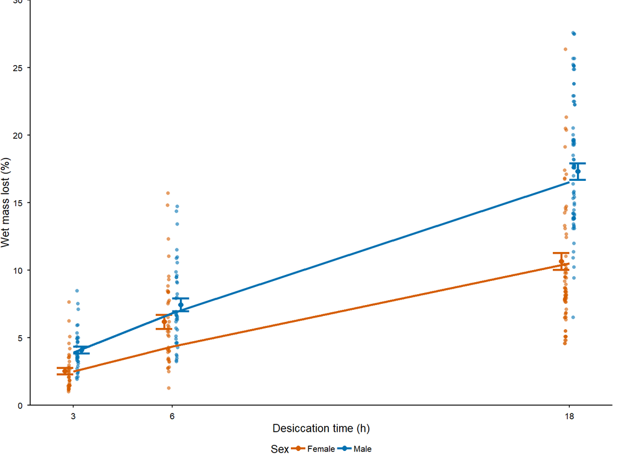

Wet mass lost (%) of female (orange) and male (blue) crickets during desiccation. Data from potassium and sodium are pooled. Lines are a fitted power function. Males lose more mass than females at all time points. Error bars are standard error around the mean.

```r
p_wetmass <- ggplot() +
  geom_point(data = drying_data %>%
               filter(!Time %in% c("0")), aes(Desiccation_time, Percent_change, colour = Sex), alpha = 0.6,
             position = position_jitterdodge(jitter.height = 0, jitter.width = 0.1, dodge = 0.5)) +
  geom_point(data = mean_pc_loss, aes(Desiccation_time, mean_pc, colour = Sex),
              size = 2, shape = 16,
             position = position_dodge(1)) +
  geom_errorbar(data = mean_pc_loss, aes(Desiccation_time, colour = Sex,
                                            ymin = mean_pc - se_pc,
                                            ymax = mean_pc + se_pc),
                width = 1, linewidth = 1,
             position = position_dodge(1)) +
  geom_line(data = PC_fit, aes(Desiccation_time, fit, colour = Sex), linewidth = 1) +
  labs(y = "Wet mass lost (%)",
       x = "Desiccation time (h)") +
  scale_shape_manual(values = sex_point) +
  scale_colour_manual(values = sex_pal) +
  scale_y_continuous(limits = c(0, 30), breaks = seq(0, 35, 5), expand = expansion(mult = c(0.0, 0))) +
  scale_x_continuous(breaks = c(0, 3, 6, 18))

p_wetmass
```

# 4 Water loss

```r
# Percentage change (water content)
mean_water_loss <- drying_data %>%
  filter(!Time %in% c("0")) %>%
  group_by(Sex, Desiccation_time) %>%
  distinct(Cricket_ID, Relative_water_loss, Sex, Desiccation_time) %>%
  summarise(mean_wl = mean(Relative_water_loss),
            se_pc = sd(Relative_water_loss) / sqrt(n()),
            range = max(Relative_water_loss) - min(Relative_water_loss),
            n = n())
knitr::kable(mean_water_loss, digits = 3)
```

| Sex | Desiccation_time | mean_wl | se_pc | range | n |
| --- | --- | --- | --- | --- | --- |
| Female | 3 | 3.754 | 0.321 | 8.616 | 39 |
| Female | 6 | 8.491 | 0.657 | 18.056 | 40 |
| Female | 18 | 15.549 | 0.795 | 28.819 | 57 |
| Male | 3 | 5.547 | 0.334 | 8.653 | 37 |
| Male | 6 | 9.830 | 0.596 | 13.743 | 39 |
| Male | 18 | 22.636 | 0.756 | 25.845 | 58 |

```r
WL_mod <- drying_data %>%
  filter(!Time %in% c("0")) %>%
  distinct(Cricket_ID, Relative_water_loss, Sex, Desiccation_time) %>%
  lm(log(Relative_water_loss) ~ log(Desiccation_time) + Sex, .)
# Interaction dropped

WL_fit <- drying_data %>%
  filter(!Time %in% c("0")) %>%
  distinct(Cricket_ID, Relative_water_loss, Sex, Desiccation_time) %>%
  select(Desiccation_time, Sex) %>%
  cbind(., exp(predict(WL_mod, newdata = ., interval = "prediction")))

summary(WL_mod)
```

```
Call:
lm(formula = log(Relative_water_loss) ~ log(Desiccation_time) +
    Sex, data = .)

Residuals:
     Min       1Q   Median       3Q      Max
-1.37171 -0.22521 -0.02284  0.27658  1.12506

Coefficients:
                      Estimate Std. Error t value             Pr(>|t|)
(Intercept)            0.42994    0.07370   5.834     0.00000001562383 ***
log(Desiccation_time)  0.79500    0.03184  24.969 < 0.0000000000000002 ***
SexMale                0.35591    0.04828   7.371     0.00000000000212 ***
---
Signif. codes:  0 '***' 0.001 '**' 0.01 '*' 0.05 '.' 0.1 ' ' 1

Residual standard error: 0.3966 on 267 degrees of freedom
Multiple R-squared:  0.7191,    Adjusted R-squared:  0.717
F-statistic: 341.7 on 2 and 267 DF,  p-value: < 0.00000000000000022
```

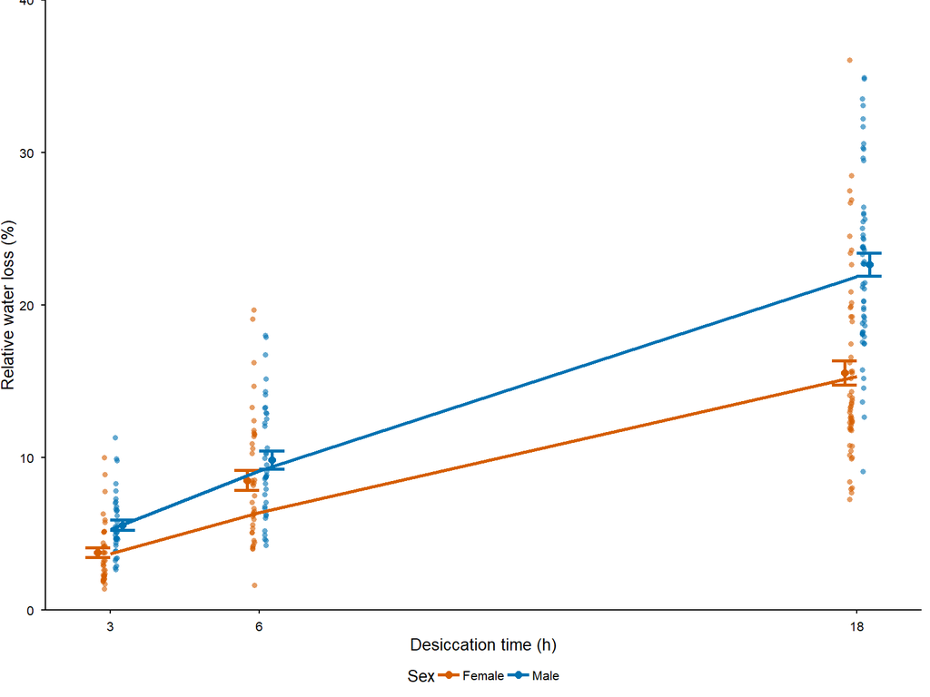

```r
p_water_loss <- ggplot() +
  geom_point(data = drying_data %>%
               filter(!Time %in% c("0")) %>% distinct(Desiccation_time, Sex, Relative_water_loss), aes(Desiccation_time, Relative_water_loss, colour = Sex), alpha = 0.6,
             position = position_jitterdodge(jitter.height = 0, jitter.width = 0.1, dodge = 0.5)) +
  geom_point(data = mean_water_loss, aes(Desiccation_time, mean_wl, colour = Sex),
              size = 2, shape = 16,
             position = position_dodge(1)) +
  geom_errorbar(data = mean_water_loss, aes(Desiccation_time, colour = Sex,
                                         ymin = mean_wl - se_pc,
                                         ymax = mean_wl + se_pc),
                width = 1, linewidth = 1,
                position = position_dodge(1)) +
  geom_line(data = WL_fit, aes(Desiccation_time, fit, colour = Sex), linewidth = 1) +
  labs(y = "Relative water loss (%)",
       x = "Desiccation time (h)") +
  scale_shape_manual(values = sex_point) +
  scale_colour_manual(values = sex_pal) +
  scale_y_continuous(limits = c(0, 40), breaks = seq(0, 50, 10), expand = expansion(mult = c(0.0, 0))) +
  scale_x_continuous(breaks = c(0, 3, 6, 18))

p_water_loss
```

## 4.1 Percentage change in mass

18 hours of desiccation is borderline where mortality occurs. Individuals that lose more than 30% of their starting mass are dead or dying. This is more likely in males than females and appears random in males; males of all sizes can lose extreme body mass. Fewer occurrences in females but those that did were smaller females.

## 4.2 Rehydration

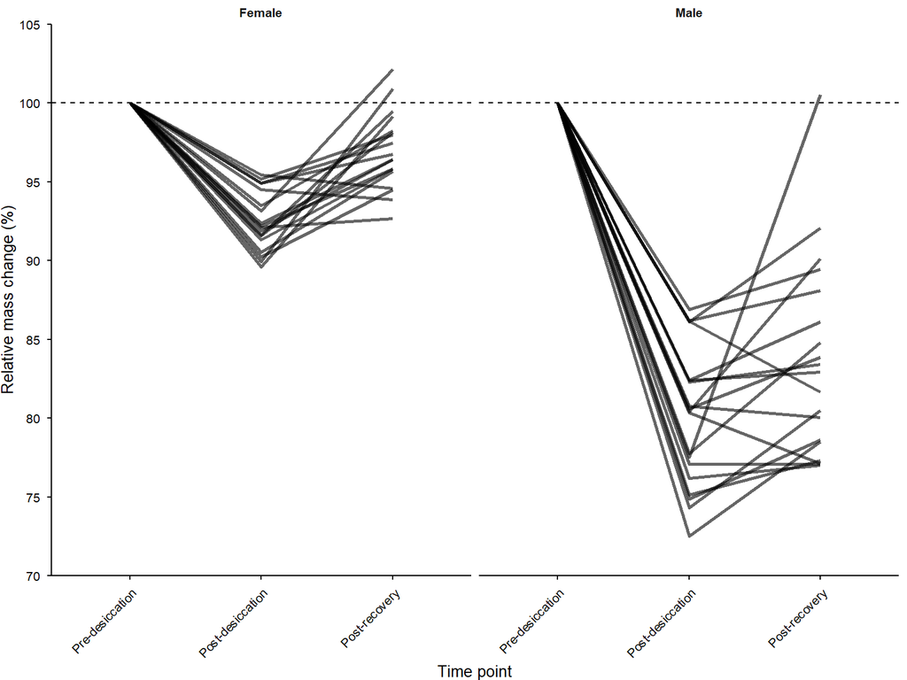

Change in mass (%) of crickets before and after desiccation and rehydration relative to their starting mass.

```r
rehydration_ions <- mass_data %>%
  filter(Time == 24,
         Survival == 1) %>%
  select(Cricket_ID, Sex, Percent_change, Percent_change_recovery) %>%
  mutate(Start_Percent = 100,
         Percent_change = 100 - Percent_change) %>%
  pivot_longer(contains("Percent"), names_to = "Timepoint", values_to = "Change") %>%
  mutate(Experiment = "Ions",
         Time_treatment = "24_starved",
         Timepoint = factor(Timepoint, levels = c("Start_Percent", "Percent_change", "Percent_change_recovery")))

ggplot(rehydration_ions, aes(Timepoint, Change, group = Cricket_ID)) +
  geom_hline(yintercept = 100, linetype = 2) +
  geom_line(linewidth = 1, alpha = 0.6) +
  theme(legend.position = "right",
        axis.text.x = element_text(angle = 45, hjust = 1)) +
  ylab("Relative mass change (%)") +
  scale_y_continuous(breaks = seq(0, 120, 5), limits = c(70, 105), expand = c(0, 0)) +
  scale_x_discrete(name = "Time point", labels = c("Pre-desiccation", "Post-desiccation", "Post-recovery")) +
  facet_grid(~Sex)
```

```r
save(mass_data, drying_data, rehydration_ions, file = "data/Desiccation 2025/ions.Rdata")
```

## 4.3 Survival curve

Losses of 45% are lethal.

```r
surv_mod <- glm(Survival ~ Relative_water_loss, mass_data, family = "binomial")
surv_fit <- data.frame(Relative_water_loss = seq(0, max(mass_data$Relative_water_loss, na.rm = TRUE)), Survival = predict(surv_mod, newdata = data.frame(Relative_water_loss = seq(0, max(mass_data$Relative_water_loss, na.rm = TRUE))), type = "response"))

log(0.5/(1-0.5)) - coef(surv_mod)[1] /coef(surv_mod)[2]
```

```
(Intercept)
   45.26193
```

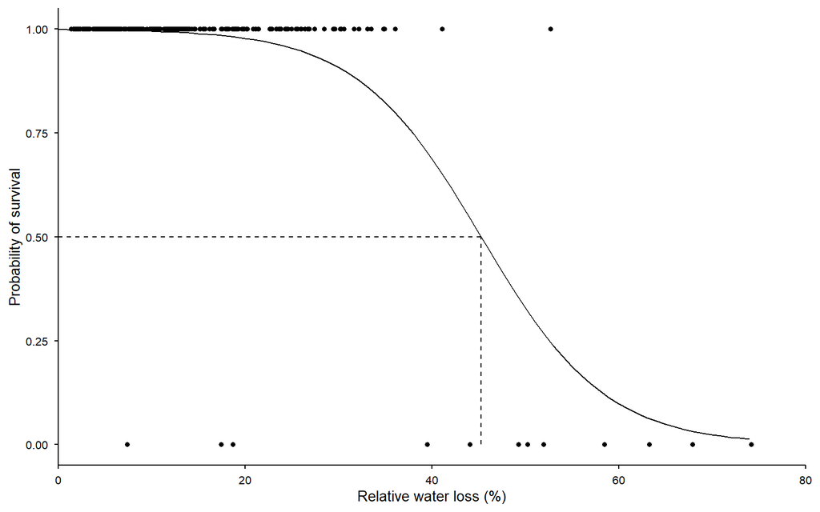

How much relative water loss (%) can a cricket tolerate before increasing the risk of mortality?

```r
surv_plot <- ggplot(mass_data, aes(Relative_water_loss, Survival), mass_data) +
  geom_point() +
  geom_line(data = surv_fit, aes(Relative_water_loss, Survival)) +
  annotate(x = log(0.5/(1-0.5)) - coef(surv_mod)[1] /coef(surv_mod)[2],
           y = 0, yend = 0.5, geom = "segment", linetype = 2) +
  annotate(xend = log(0.5/(1-0.5)) - coef(surv_mod)[1] /coef(surv_mod)[2],
           x = 0, y = 0.5, geom = "segment", linetype = 2) +
  scale_x_continuous(limits = c(0, 80), expand = c(0, 0)) +
  theme(plot.margin = margin(t = 6, r = 10, b = 6, l = 6, unit = "pt")) +
  labs(y = "Probability of survival",
       x = "Relative water loss (%)")

surv_plot
```

```r
ggsave(surv_plot, dpi = 300, width = ppt_width, units = "mm", height = ppt_height, filename = "data/Desiccation 2025/figures/ion_survival.png")
```

# 5 Publication figures